# Eksploracja danych

pogRomcy danych

sezon 2 / odcinek 12  
[Przemysław Biecek @ Uniwersytet Warszawski](http://biecek.pl/)  
Naciśnij `A` by zamienić slajdy na ciągły tekst.  
Naciśnij `T` by wyświetlić spis treści.

# O czym jest ten odcinek?

Zanim zacznie się budować modele, zanim rozpocznie się zaawansowaną analizę danych, wcześniej zawsze warto przyjrzeć się bliżej danym.

Takie przyglądanie się danym, często bez konkretnego celu, nazywa się eksploracją.

Pierwsze spojrzenie na dane. Sprawdzenie z jakimi zmiennymi, z jakimi zakresami zmiennych, jakimi relacjami pomiędzy zmiennymi mamy do czynienia.

Eksplorację często zaczyna się od przyjrzenia każdej ze zmiennych osobno, ewentualnie parami, bazując na prostych podsumowaniach graficznych lub tabelarycznych.

W tym odcinku pokażemy jak przedstawiać rozkład zmiennej ilościowej oraz zmiennej jakościowej, za pomocą kilku popularnych statystyk.

Dla zmiennej ilościowej (liczbowej) przedstawimy

- średnią, medianę,
- pięć liczb Tukeya,
- wykres ramka wąsy, histogram.

Dla zmiennej jakościowej (z kategoriami) przedstawimy

- tablice kontyngencji,
- sortowanie.

# Baza danych o filmach i serialach

W bazie danych o filmach IMDB (Internet Movie Database) znaleźć można różne ciekawe dane o serialach. W szczególności średnie oceny użytkowników wystawione kolejnym odcinkom serialu.

Przykładowo, na stronie http://www.imdb.com/title/tt0903747/epdate?ref_=ttep_ql_4 znajdują się oceny serialu *Breaking Bad*.

Na potrzeby tego odcinka pobraliśmy dane z Internetu, oczyściliśmy je i udostępniliśmy w zbiorze danych `serialeIMDB` w pakiecie `PogromcyDanych`, który towarzyszy temu kursowi.

Cały zbiór danych jest dosyć duży, wszystkich odcinków wszystkich seriali jest ponad 20 tysięcy wierszy, każdy opisany przez 8 kolumn/zmiennych.

Wczytujemy zbiór danych, jeżeli nie jest zainstalowany to należy go zainstalować poleceniem `install.packages("PogromcyDanych")`.

```r
library(PogromcyDanych)
```

Sprawdzamy wielkość zbioru danych.

```r
dim(serialeIMDB)
```

```
## [1] 20122     8
```

Wyświetlmy pierwsze 6 wierszy. W kolejnych kolumnach jest nazwa serialu, nazwa odcinka, numer sezonu, numer odcinka, średnia ocena, liczba oddanych głosów, oraz identyfikator z bazy IMDB.

```r
head(serialeIMDB)
```

```
##   id       serial                         nazwa sezon odcinek ocena glosow    imdbId
## 1  1 Breaking Bad                         Pilot     1       1   8.7   9357 tt0903747
## 2  2 Breaking Bad           Cat's in the Bag...     1       2   8.2   6506 tt0903747
## 3  3 Breaking Bad ...And the Bag's in the River     1       3   8.3   6176 tt0903747
## 4  4 Breaking Bad                    Cancer Man     1       4   7.9   5796 tt0903747
## 5  5 Breaking Bad                   Gray Matter     1       5   7.9   5664 tt0903747
## 6  6 Breaking Bad      Crazy Handful of Nothin'     1       6   8.7   6521 tt0903747
```

# Seriale

Kolumna danych o nazwie `serial` jest zmienną jakościową, przyjmującą za wartości nazwy seriali. Listę poziomów zmiennej jakościowej można wyświetlić funkcją `levels()`.

Zapis `serialeIMDB$serial` oznacza odwołanie się do kolumny `serial` ze zbioru danych `serialeIMDB`.

Z jakimi serialami mamy do czynienia w tym zbiorze danych?

```r
levels(serialeIMDB$serial)
```

```
##   [1] "Breaking Bad"
##   [2] "Cosmos: A Space-Time Odyssey"
##   [3] "Planet Earth"
##   [4] "Game of Thrones"
##   [5] "True Detective"
##   [6] "The Wire"
##   [7] "Sherlock"
##   [8] "Cosmos"
##   [9] "The Sopranos"
##  [10] "Leyla ile Mecnun"
##  [11] "Firefly"
##  [12] "Arrested Development"
##  [13] "I, Claudius"
##  [14] "Avatar: The Last Airbender"
##  [15] "Life"
```

[output cut: 183 more lines]

# Tabela liczebności

Kolumna `serialeIMDB$serial` zawiera nazwy seriali. Te nazwy powtarzają się dla każdego serialu tyle razy, ile odcinków jest opisanych w zbiorze danych. Użyteczną funkcją do eksploracji zmiennych jakościowych jest tabela częstości. Przedstawia ona jak często określona wartość występuje w wektorze.

Tabelę częstości można wyznaczyć funkcją `table()`. Wynik tej funkcji można wyświetlić na ekranie lub, jak w poniższym przykładzie, zapisać do zmiennej.

```r
tabela <- table(serialeIMDB$serial)
# pierwsze 6 wartości z wektora
head(tabela)
```

```
##
##                 Breaking Bad Cosmos: A Space-Time Odyssey                 Planet Earth
##                           62                           13                           11
##              Game of Thrones               True Detective                     The Wire
##                           40                            8                           60
```

Tabelę liczebności dla 200 seriali trudno się przegląda. Jeżeli interesują nas najczęstsze lub najrzadsze wartości to aby je odczytać warto tabelę liczebności posortować (funkcja `sort()`).

Po posortowaniu w sposób malejący (argument `decreasing = TRUE`) najczęstsze wartości znajdą się na początku a najrzadsze na końcu posortowanego wektora.

Ponad 500 odcinków dla Simpsonów? Robi wrażenie.

```r
sort(tabela, decreasing = TRUE)
```

```
##
##          The Daily Show with Jon Stewart                       The Colbert Report
##                                     1814                                     1067
##                               Doctor Who                                One Piece
##                                      819                                      679
##                            Dragon Ball Z                             The Simpsons
##                                      589                                      564
##                        Naruto: Shippuden                                 Top Gear
##                                      397                                      276
##                              MythBusters                               South Park
##                                      258                                      257
##                                  M*A*S*H                   The Andy Griffith Show
##                                      251                                      249
##                               Family Guy                                  Friends
##                                      240                                      238
##                 Whose Line Is It Anyway?                            Stargate SG-1
##                                      214                                      213
##                             Supernatural                    How I Met Your Mother
##                                      208                                      208
##                        All in the Family            Late Night with Conan O'Brien
##                                      208                                      205
##                               The Office                              The X-Files
##                                      201                                      201
##             Mystery Science Theater 3000                                       24
##                                      197                                      195
##                           Adventure Time                                   Scrubs
##                                      182                                      182
##                              I Love Lucy                                       QI
##                                      181                                      179
##                               House M.D.           Star Trek: The Next Generation
##                                      176                                      176
##                      The Big Bang Theory                                 Seinfeld
##                                      173                                      172
##                        Dragon Ball Z Kai                             Regular Show
##                                      168                                      167
##                            Twilight Zone                            The West Wing
##                                      156                                      155
##                              Dragon Ball                               Dragonball
##                                      153                                      151
##                The Angry Video Game Nerd                                   Castle
```

[output cut: 144 more lines]

```
##                                       12                                       12
##                                   Utopia                             Planet Earth
##                                       12                                       11
##                                 Sherlock                        Hellsing Ultimate
##                                       11                                       10
##                           True Detective                      Summer Heights High
##                                        8                                        8
##                             Black Mirror                          The Black Adder
##                                        7                                        7
##                    Blackadder Goes Forth                           Black-Adder II
##                                        6                                        6
##                    Black Adder the Third               Garth Marenghi's Darkplace
##                                        6                                        6
##                            Police Squad!                                     FLCL
##                                        6                                        6
```

# Breaking Bad

Cały zbiór danych o serialach ma ponad 20 tysięcy wierszy. Praca na tak dużym zbiorze danych, o wszystkich serialach jest z różnych powodów trudna. Między innymi dlatego, że nie jesteśmy w stanie ogarnąć wzrokiem wszystkich 20 tysięcy wierszy.

Na potrzeby dalszych przykładów wybierzmy z tego zbioru danych jeden serial, któremu przyjrzymy się bliżej. Na tych slajdach będzie to *Breaking Bad*, ale warto samodzielnie poeksperymentować również z innymi serialami.

Funkcją `filter()` wybieramy tylko wiersze dla serialu Breaking Bad.

```r
BreakingBad <- filter(serialeIMDB, serial == "Breaking Bad")
```

O ilu odcinkach dostępna jest informacja dla tego serialu?

```r
dim(BreakingBad)
```

```
## [1] 62  8
```

A jak wyglądają dane dla serialu *Star Trek: The Next Generation*?

```r
filter(serialeIMDB, serial == "Star Trek: The Next Generation")
```

```
##      id                         serial                           nazwa sezon odcinek
## 1     1 Star Trek: The Next Generation           Encounter at Farpoint     1       1
## 2     2 Star Trek: The Next Generation                   The Naked Now     1       2
## 3     3 Star Trek: The Next Generation                   Code of Honor     1       3
## 4     4 Star Trek: The Next Generation                The Last Outpost     1       4
## 5     5 Star Trek: The Next Generation    Where No One Has Gone Before     1       5
## 6     6 Star Trek: The Next Generation                 Lonely Among Us     1       6
## 7     7 Star Trek: The Next Generation                         Justice     1       7
## 8     8 Star Trek: The Next Generation                      The Battle     1       8
## 9     9 Star Trek: The Next Generation                      Hide and Q     1       9
## 10   10 Star Trek: The Next Generation                           Haven     1      10
## 11   11 Star Trek: The Next Generation                 The Big Goodbye     1      11
## 12   12 Star Trek: The Next Generation                        Datalore     1      12
## 13   13 Star Trek: The Next Generation                       Angel One     1      13
## 14   14 Star Trek: The Next Generation                        11001001     1      14
```

[output cut: 339 more lines]

# Co się dzieje z ocenami odcinków?

Co ciekawego możemy zrobić z danymi dla jednego serialu?

Z pewnością interesującą informacją są oceny danego serialu. Ta informacja dostępna jest w kolumnie `ocena` i można się do niej dostać odwołując się do tej kolumny operatorem `$`.

Ale przecież każdy odcinek podobał się inaczej, jeden bardziej inny mniej. Porównajmy trzy sposoby przedstawienia informacji o ocenach. Czy któryś z tych sposobów prezentacji liczb pozwala na zauważenie czegoś ciekawego?

Odcinki są uporządkowane zgodnie z datą emisji.

1. Sposób pierwszy: wektor liczb

```r
BreakingBad$ocena
```

```
##  [1]  8.7  8.2  8.3  7.9  7.9  8.7  8.4  8.1  8.7  7.9  7.8  7.8  8.3  8.2  8.5  8.5  8.0
## [18]  8.2  8.6  8.6  8.0  8.1  7.8  7.7  8.0  8.6  9.0  8.1  7.8  7.4  7.9  8.9  9.1  8.6
## [35]  7.8  7.6  8.1  8.1  7.8  8.2  8.6  8.2  9.1  9.2  8.8  9.7  8.8  8.4  8.4  8.3  9.3
## [52]  8.5  9.0  9.2  9.0  8.7  9.2  8.6  9.6 10.0  9.4  9.9
```

# Co się dzieje z ocenami odcinków?

2. Sposób drugi: wykres słupkowy, wysokość słupka odpowiada ocenie.

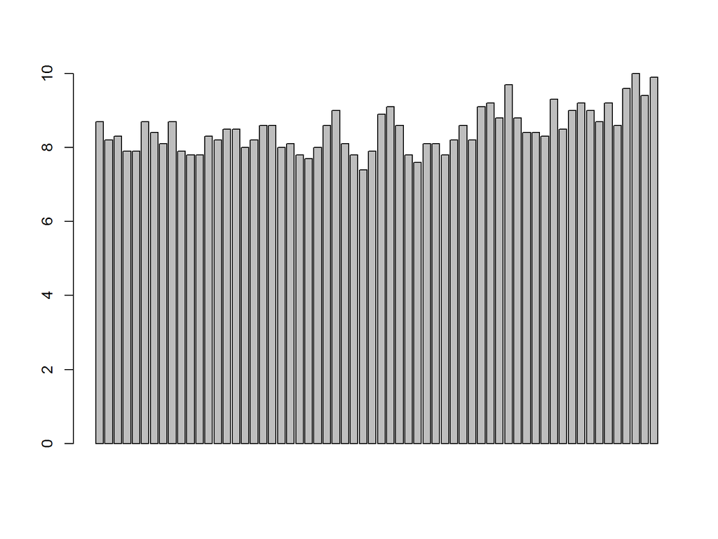

```r
barplot(BreakingBad$ocena)
```

# Co się dzieje z ocenami odcinków?

3. Sposób trzeci: wykres punktowy, pozycja punktu odpowiada ocenie odcinka.

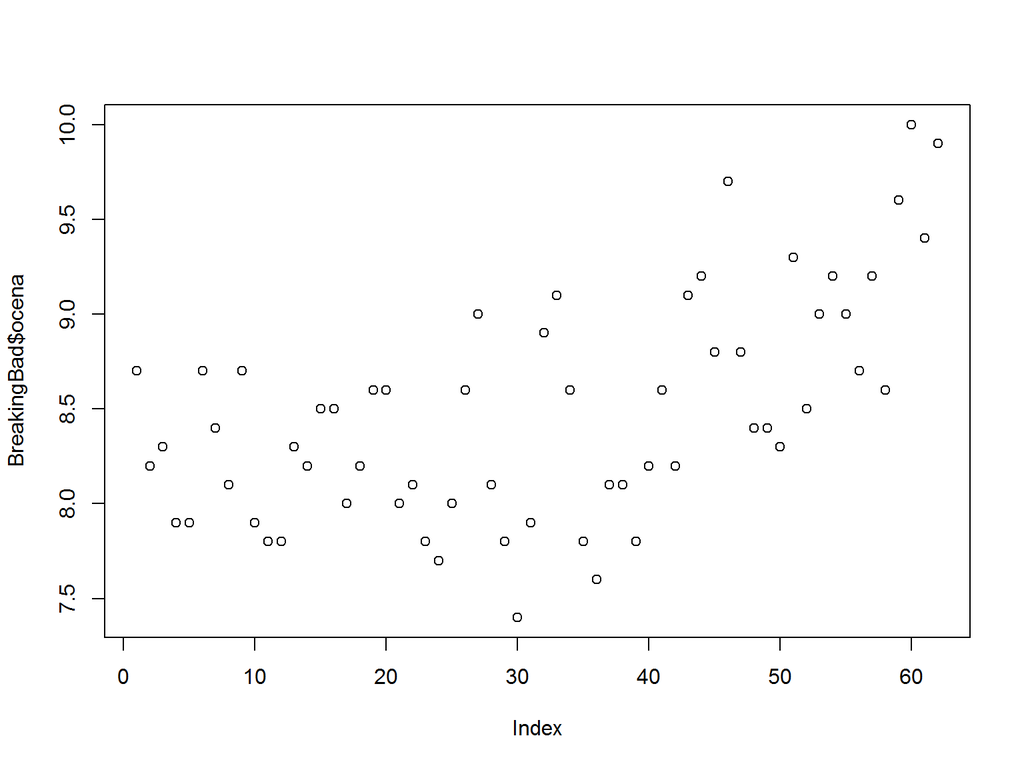

```r
plot(BreakingBad$ocena)
```

# Sortowanie

Często interesujące obserwacje to skrajne obserwacje.

Ale jak najłatwiej się zorientować które odcinki uzyskują skrajne oceny?

Najłatwiej posortować odcinki po ocenie i wyświetlić taki posortowany zbiór danych. Na początku będą te o skrajnie niskich ocenach, na końcu te o skrajnie wysokich ocenach.

```r
arrange(BreakingBad, ocena)
```

```
##    id       serial                         nazwa sezon odcinek ocena glosow    imdbId
## 1  30 Breaking Bad                           Fly     3      10   7.4   7737 tt0903747
## 2  36 Breaking Bad                    Open House     4       3   7.6   4762 tt0903747
## 3  24 Breaking Bad                   Green Light     3       4   7.7   4561 tt0903747
## 4  11 Breaking Bad                          Down     2       4   7.8   4932 tt0903747
## 5  12 Breaking Bad                      Breakage     2       5   7.8   4855 tt0903747
## 6  23 Breaking Bad                        I.F.T.     3       3   7.8   4613 tt0903747
## 7  29 Breaking Bad                    Kafkaesque     3       9   7.8   4591 tt0903747
## 8  35 Breaking Bad             Thirty-Eight Snub     4       2   7.8   4853 tt0903747
## 9  39 Breaking Bad                      Cornered     4       6   7.8   4716 tt0903747
## 10  4 Breaking Bad                    Cancer Man     1       4   7.9   5796 tt0903747
## 11  5 Breaking Bad                   Gray Matter     1       5   7.9   5664 tt0903747
## 12 10 Breaking Bad             Bit by a Dead Bee     2       3   7.9   5025 tt0903747
## 13 31 Breaking Bad                       Abiquiu     3      11   7.9   4623 tt0903747
## 14 17 Breaking Bad                          Over     2      10   8.0   4901 tt0903747
```

[output cut: 48 more lines]

# Jak oceniano ten serial?

Dla serialu Breaking Bad mamy dostępną informację o 62 odcinkach.

Każdy z nich ma określoną średnią ocenę, ale czasem chcielibyśmy myśleć o wszystkich odcinkach jak o pewnej całości. Czy cały serial jest dobry czy nie?

Jak podsumować oceny z 62 odcinków?

Dwa najpopularniejsze podejścia to średnia oraz mediana (czyli element środkowy). Można je prosto wyznaczyć funkcjami `mean()` i `median()`.

```r
mean(BreakingBad$ocena)
```

```
## [1] 8.480645
```

```r
median(BreakingBad$ocena)
```

```
## [1] 8.4
```

Mediana to wartość, która po posortowaniu całego wektora znajduje się w środku (lub dla parzystej liczby wartości, jest to średnia z dwóch środkowych wartości).

Więcej informacji niż sama średnia czy mediana, niesie tak zwanych pięć liczb Tukeya. Można je wyznaczyć (razem ze średnią arytmetyczną) funkcją `summary()`. Te pięć liczb przedstawia:

- `Min` ocenę najgorszego odcinka,
- `Max` ocenę najlepszego odcinka,
- `Median` ocenę środkowego odcinka (jeżeli jest nieparzysta liczba odcinków) lub średnią z dwóch środkowych odcinków (jeżeli jest parzysta liczna odcinków),
- `1st Qu.` i `3rd Qu.`, czyli oceny ćwiartkowe (połowa obserwacji od minimum do mediany i od mediany do maksimum).

Pięć liczb Tukeya dzieli wartości na cztery równoliczne grupy.

```r
summary(BreakingBad$ocena)
```

```
##    Min. 1st Qu.  Median    Mean 3rd Qu.    Max.
##   7.400   8.025   8.400   8.481   8.800  10.000
```

# Pięć liczb - wykres pudełko wąsy

Pięć liczb Tukeya można przedstawić graficznie. Służy do tego wykres nazywany pudełko-wąsy lub ramka-wąsy lub z angielskiego boxplot.

Jest na tym wykresie pięć poziomych odcinków i każdy odpowiada jednej z pięciu liczb Tukeya.

Pomiędzy sąsiednimi poziomymi liniami mieści się tyle samo wartości. Jeżeli jednej z tych odcinków jest dłuższy niż pozostałe, to oznacza że wartości w nim są rzadsze niż w innych.

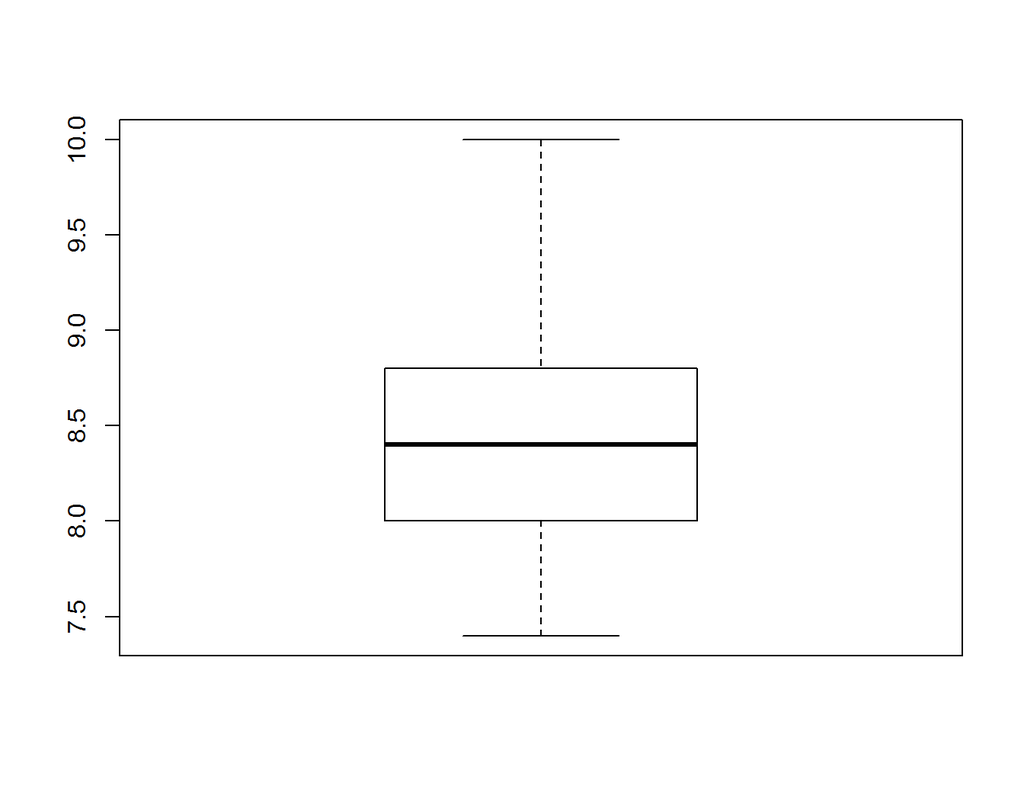

```r
boxplot(BreakingBad$ocena )
```

# Pięć liczb - wykres pudełko wąsy

Zaletą wykresu pudełko - wąsy jest to, że pozwala łatwiej i lepiej porównać grupy obserwacji.

Zobaczmy jak oceny odcinków różnią się pomiędzy sezonami.

Jak to zrobić w programie R? W funkcji `boxplot()` użyjemy znaku formuły `~` aby określić, że chcemy przedstawiać oceny w podziale na sezony. Lewa strona tego symbolu określa zmienną którą chcemy podsumować, a prawa strona określa grupy, które chcemy porównać.

Co możemy odczytać z takiej reprezentacji danych? Naprawdę wiele rzeczy. Spróbujmy zmierzyć się z tym zagadnieniem przez chwilę samodzielnie. Na poniższym wykresie znajdźmy trzy ciekawe obserwacje.

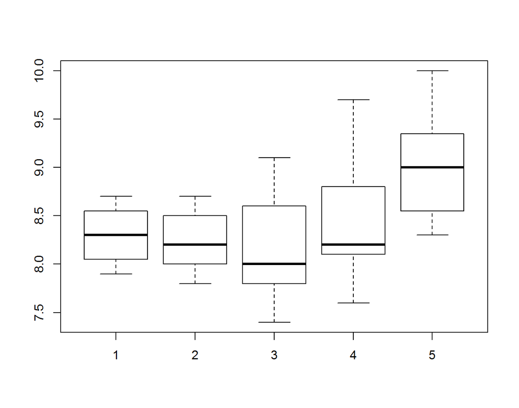

```r
BreakingBad$sezon <- droplevels(BreakingBad$sezon)
boxplot(BreakingBad$ocena ~ BreakingBad$sezon)
```

# Pięć liczb - wykres pudełko wąsy

Co ciekawego udało się znaleźć? Dla mnie najciekawsze obserwacje to:

1. Najlepsze oceny ma sezon 5. Jego mediana jest powyżej całego pudełka dla sezonów 1 i 2, co oznacza, że ponad połowa odcinków z sezonu 5 była wyżej oceniana niż najlepszy z odcinków z pierwszych dwóch sezonów.
2. Najsłabsze wyniki notuje sezon 3. W nim to znajduje się odcinek najgorzej oceniany. Również dla tego sezonu obserwujemy najniższą medianę.
3. Największą zmienność obserwuje się dla sezonu 4. Był w nim i bardzo słaby odcinek (jak na ten serial) i bardzo dobry odcinek.

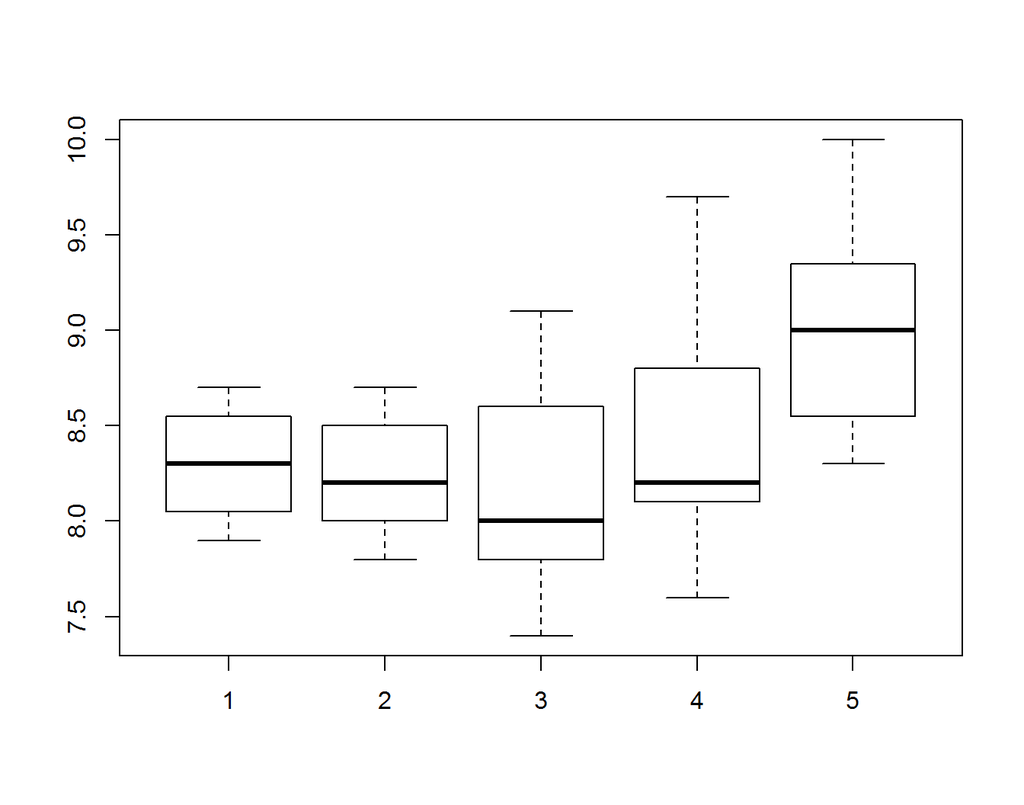

# Histogram

Jak inaczej można przedstawić rozkład ocen?

Interesującą alternatywą jest histogram. Zasada prezentacji danych jest następująca:

Dzielimy zakres wartości na pewną liczbę (poniżej na `breaks = 10`) przedziałów o równej długości. Następnie w każdym przedziale sprawdzamy ile wartości do niego wpada. Na wykresie oznaczamy wysokością słupka liczbę obserwacji, które wpadły do określonego przedziału.

Im wyższe słupki, tym większe zagęszczenie obserwacji w danym przedziale.

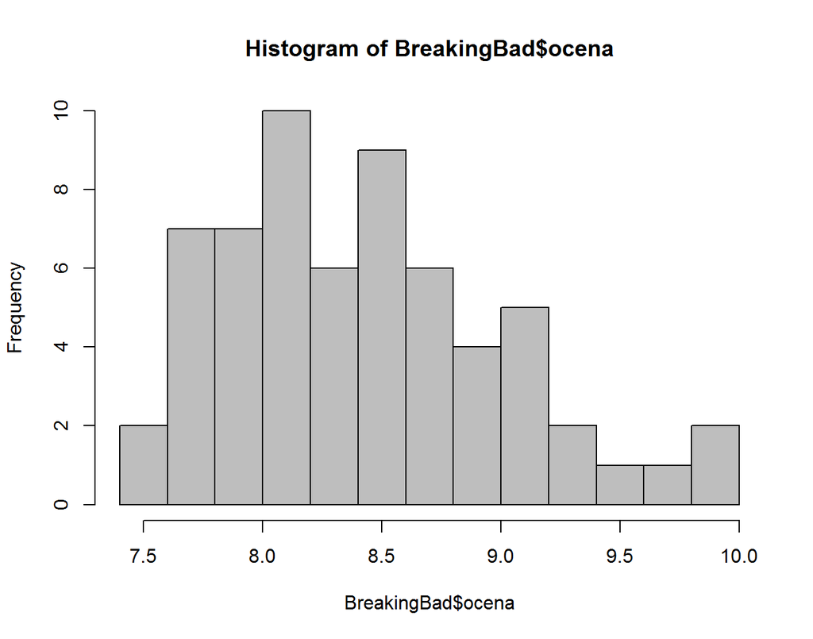

```r
hist(BreakingBad$ocena, breaks = 10, col="grey")
```

# Co może dać nam histogram czego nie dają inne miary?

Histogram jest bardziej skomplikowanym wykresem niż wykres pudełkowy.

Pytanie czy ta komplikacja niesie użyteczną informację?

Takiej informacji nie sposób odczytać ze zwykłego wykresu ramka-wąsy.

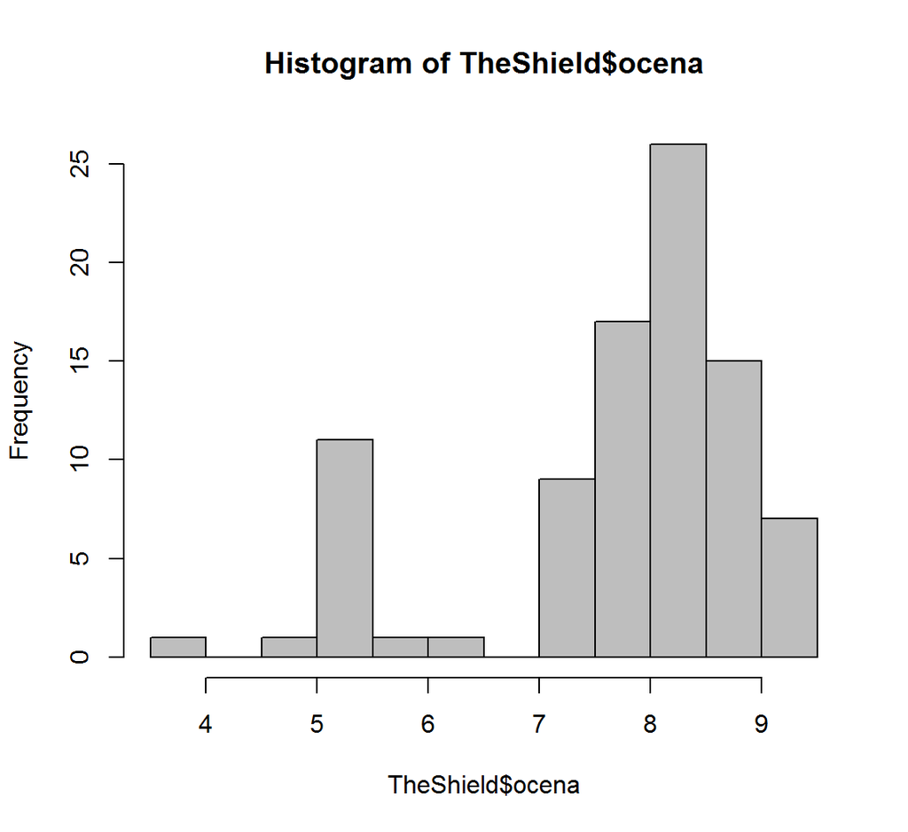

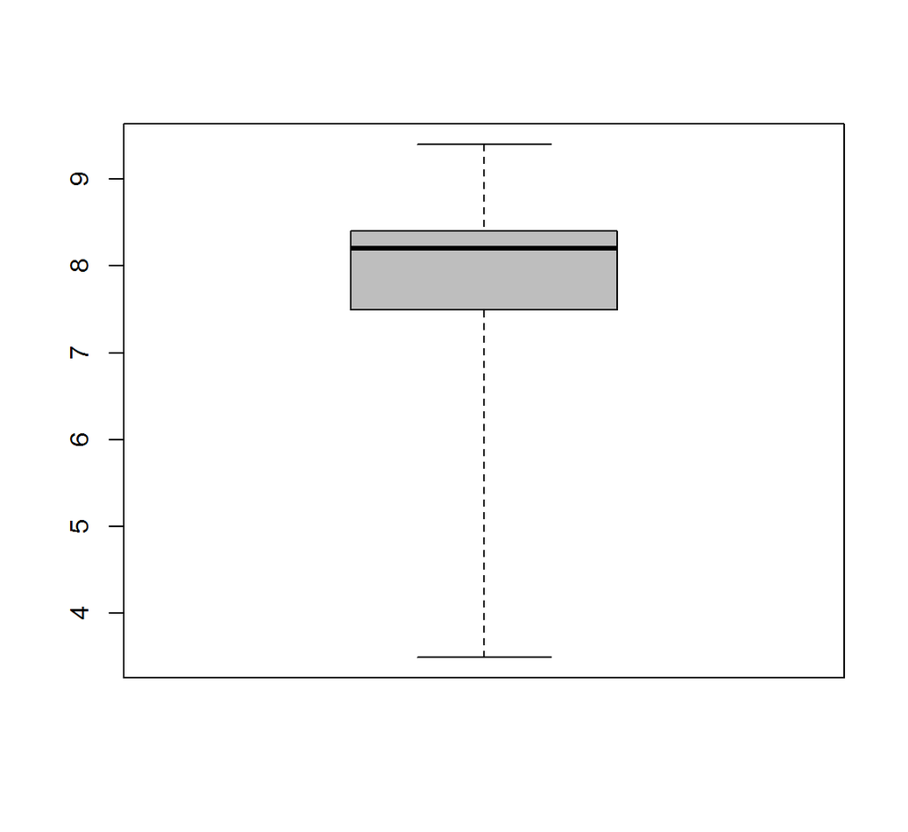

```r
TheShield <- filter(serialeIMDB, serial == "The Shield")
hist(TheShield$ocena, 10, col="grey")
boxplot(TheShield$ocena, col="grey", range = 10)
```

# Podsumowanie instrukcji R

W tym odcinku omawialiśmy funkcje służące do eksploracji liczbowej i graficznej danych ilościowych.

```r
# pakiet z danymi
library(PogromcyDanych)

# wielkość danych i kilka pierwszych wierszy
dim(serialeIMDB)
head(serialeIMDB)

# wartości zmiennych jakościowych
levels(serialeIMDB$serial)

# jak wyznaczyć tabelę liczebności i ją posortować
tabela <- table(serialeIMDB$serial)
sort(tabela, decreasing = TRUE)

# wybieramy tylko dane dotyczące serialu Breaking Bad
BreakingBad <- filter(serialeIMDB, serial == "Breaking Bad")
# o ilu odcinkach dostępna jest informacja dla tego serialu?
dim(BreakingBad)

# różne sposoby oglądania informacji o odcinkach
BreakingBad$ocena
barplot(BreakingBad$ocena)
plot(BreakingBad$ocena)
```

# Podsumowanie instrukcji R

W tym odcinku omawialiśmy funkcje służące do eksploracji liczbowej i graficznej danych ilościowych.

```r
# sortowanie danych
arrange(BreakingBad, ocena)

# podsumowanie danych o ocenach
summary(BreakingBad$ocena)

# wykres pudełkowy
boxplot(BreakingBad$ocena )

# wykres pudełkowy dla grup
BreakingBad$sezon <- droplevels(BreakingBad$sezon)
boxplot(BreakingBad$ocena ~ BreakingBad$sezon)

# histogram a więc pełna informacja o rozkładzie
hist(BreakingBad$ocena, 10, col="grey")

# kiedy histogram zdradza dodatkowe informacje
TheShield <- filter(serialeIMDB, serial == "The Shield")
hist(TheShield$ocena, 10, col="grey")
boxplot(TheShield$ocena, col="grey", range = 10)
```

# Zadania

- Wybierz serial *Friday Night Lights* zobacz jak wygląda popularność tego serialu. Czy jest bardziej popularny niż *Breaking Bad*?
- Zobacz jak popularność tego serialu zmieniała się w czasie. Czy zaobserwowałeś coś interesującego?
- Zamiast prezentować informacje o ocenach odcinków przedstaw informacje o liczbie oddanych głosów (popularności) odcinków. Czy te same statystyki nadają się równie dobrze do prezentacji informacji o ocenie i o liczbie głosów?